# City name challenge

### The challenge

Are there more cities with UK names on the east coast of the US or on the west coast of the US?  
Dataset: http://download.maxmind.com/download/worldcities/worldcitiespop.txt.gz

### Importing data

First we import the data from the file ‘worldcitiespop.txt’ into a dataframe:

```r
complete <- read.csv("worldcitiespop.txt", stringsAsFactors = FALSE)
```

Then we extract and save the relevant subsets, US cities and UK cities:

```r
complete_us=complete[complete$Country=="us",]
save(complete_us,file="data_us.Rda")
complete_uk=complete[complete$Country=="gb",]
save(complete_uk,file="data_uk.Rda")
```

After saving, the data can be quickly loaded:

```r
load("data_us.Rda")
load("data_uk.Rda")
```

### Cleaning data

Before cleaning, we create a backup copy of the data that will be modified:

```r
complete_us_orig=complete_us
```

Some city names contain “bad” non-UTF-8 format. Check how many:

```
## Records with non UTF-8 city name format:
## in US
##         Country           City     AccentCity Region Population  Latitude
## 2912712      us      it\xfc`au      It\xfc`au     AS         NA -14.34778
## 2921665      us pi\xf1on hills Pi\xf1on Hills     CA         NA  34.43333
##         Longitude
## 2912712 -170.7664
## 2921665 -117.6458
## in UK
## [1] Country    City       AccentCity Region     Population Latitude
## [7] Longitude
## <0 rows> (or 0-length row.names)
```

There are few values; we just convert to NA:

```r
complete_us$City=iconv(complete_us$City,from="",to="UTF-8")
```

Potentially we may want to filter data by population, but only < 3% of initial data would be left:

```r
nrow(complete_us[!is.na(complete_us$Population) & complete_us$Population>0,])/nrow(complete_us_orig)
```

```
## [1] 0.02940369
```

For the moment we avoid population filtering:

```r
cat("Percentage of initial data used: ", 100*nrow(complete_us)/nrow(complete_us_orig),"\n")
```

```
## Percentage of initial data used:  100
```

### Elaborating data

First thing is to establish an UK name identity; there are many possible approaches.  
An easy approach is just to get the list of UK city names from the dataset,

```r
uk_names=unique(complete_uk$City)
```

and identify US city names exactly matching elements in this list:

```r
us_cities_uk=complete_us[tolower(complete_us$City) %in% tolower(uk_names),]
```

A second method relies on using pattern matching, but it is much slower with the full dataset (~ 40 min on my laptop).

### Results for east and west coasts

US states on the coasts according to Wikpedia definition (east coast set includes some states without shoreline, west coast set excludes Alaska):

```r
east_us=c("FL","GA","SC","NC","VA","MD","DE","NJ","NY","CT","RI","MA","NH","ME","PA","DC","VT","WV");
west_us=c("CA","OR","WA");
```

Select cities in coast states:

```r
west_us_cities=complete_us[tolower(complete_us$Region) %in% tolower(west_us),];
east_us_cities=complete_us[tolower(complete_us$Region) %in% tolower(east_us),];
```

Select cities with UK names in coast states:

```r
west_us_cities_uk=us_cities_uk[tolower(us_cities_uk$Region) %in% tolower(west_us),];
east_us_cities_uk=us_cities_uk[tolower(us_cities_uk$Region) %in% tolower(east_us),];
```

Print results:

```
##
##  Total number of cities in US:  141989
## Total number of cities with UK name in US:  9535
## Percentage of UK names in US:  0.06715309
##
##  Total number of cities in west coast:  9115
## Total number of cities with UK name in west coast:  553
## Percentage of UK names in west coast:  0.06066923
##
##  Total number of cities in east coast:  59887
## Total number of cities with UK name in east coast:  3610
## Percentage of UK names in east coast:  0.06028019
```

Plotting spatial data: cities with UK name

[figure not shown]

```r
map <- qmap('US',zoom=3)
#plot the city points on top
map <- map + geom_point(data = east_us_cities_uk,
                        aes(x = Longitude, y = Latitude),
                        color="red", size=0.7, alpha=0.5) +
  geom_point(data = west_us_cities_uk,
             aes(x = Longitude, y = Latitude),
             color="red", size=0.7, alpha=0.5)

show(map)
```

### Results for each state in US

We now perform an analysis at level of single state in US. First we get a list of the “continental” states in US:

```r
us_states=unique(complete_us$Region)
us_states_extra=c("AS","GU","MP","PR","VI","UM","FM","MH","PW","HI")
us_states_50=us_states[!(us_states %in% us_states_extra)] # excluding Hawaii
```

Then we generate a dataframe containing number of cities, number of cities with UK name, and percentage for each state:

```r
dfStates <- all_states(complete_us,us_cities_uk,us_states_50)
head(dfStates)
```

```
##   code_state nrCities nrCitiesUK fractionUK
## 1         AL     4258        270 0.06341005
## 2         AK      677         23 0.03397341
## 3         AZ     1926         60 0.03115265
## 4         AR     3158        238 0.07536415
## 5         CA     5436        243 0.04470199
## 6         CO     1494        115 0.07697456
```

We can make a histogram:

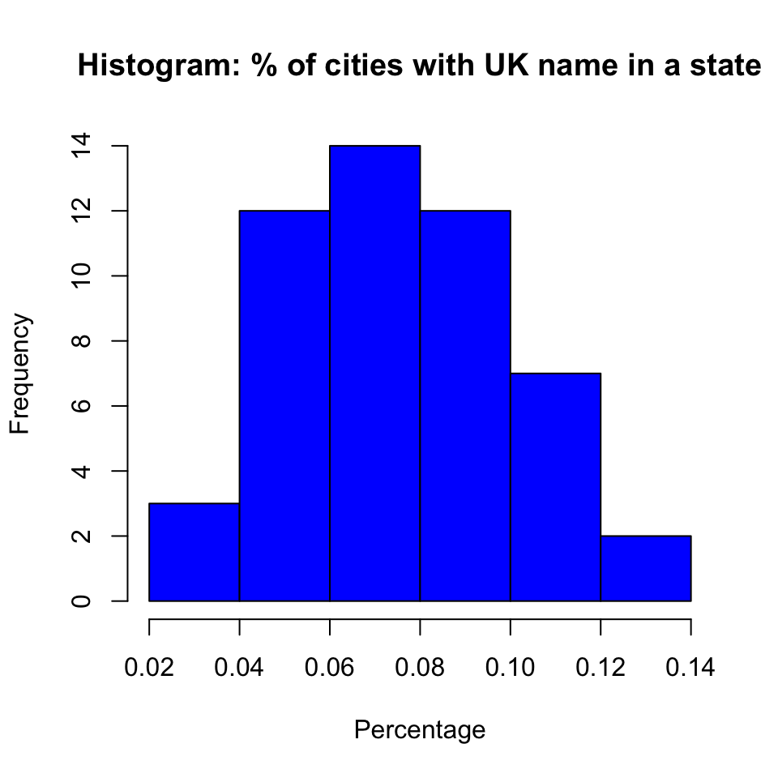

```r
hist(dfStates$fractionUK,
     main="Histogram: % of cities with UK name in a state",
     xlab="Percentage",
     col="blue")
```

and give an estimate of the statistics for the states on the coasts:

```r
mean_east <- mean(dfStates$fractionUK[dfStates$code_state %in% east_us])
sd_east <- sd(dfStates$fractionUK[dfStates$code_state %in% east_us])
mean_west <- mean(dfStates$fractionUK[dfStates$code_state %in% west_us])
```

```
##
##  Percentage of cities with UK name, state by state:
## East coast mean and sd:  0.07369821 0.02731128
## West coast mean:  0.07113871
```

Bar plot of states reordered according percentage of UK city names:

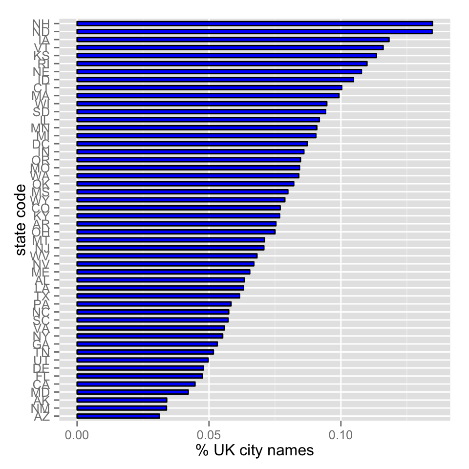

```r
ggplot(dfStates, aes(x = reorder(code_state, fractionUK), y = fractionUK))+
  geom_bar(colour="black", fill="blue", width=0.5, position = position_dodge(width = 3), stat = "identity") +
  ylab("% UK city names") + xlab("state code") +
  coord_flip() +
  guides(fill=FALSE)
```

Many states in the southern parth of US have the lowest percentage; this could reflect the importance of Spaniard colonization in those states.

### Appendix

Function “all_states”, to generate the dataframe for each US state:

```r
all_states <- function(total_us,total_us_uk,us_states){
  #compute nr of cities, uk cities and percentage for each state
  nr_cities=vector('numeric')
  nr_cities_uk=vector('numeric')
  percent=vector('numeric')
  for (i in (1:length(us_states))){
    state=us_states[i]
    nr_cities_uk[i]=nrow(total_us_uk[tolower(total_us_uk$Region)==tolower(state),])
    nr_cities[i]=nrow(total_us[tolower(total_us$Region)==tolower(state),])
    percent[i]=nr_cities_uk[i]/nr_cities[i]
  }
  dfStates=data.frame(code_state=us_states,
                      nrCities=nr_cities,
                      nrCitiesUK=nr_cities_uk,
                      fractionUK=percent)
  return(dfStates)
}
```